# Graded Project Python for DS

```python
#Import the required libraries and read the data set
import numpy as np
import datetime
import pandas as pd
import matplotlib.pyplot as plt
import seaborn as sns
import sklearn
from sklearn.model_selection import train_test_split
from sklearn.preprocessing import StandardScaler, LabelEncoder

import warnings
warnings.filterwarnings('ignore')

from sklearn.metrics import accuracy_score, confusion_matrix
from sklearn.linear_model import LogisticRegression
from sklearn.naive_bayes import GaussianNB
from sklearn.neighbors import KNeighborsClassifier
from sklearn.tree import DecisionTreeClassifier
from sklearn.ensemble import RandomForestClassifier, BaggingClassifier, AdaBoostClassifier, GradientBoostingClassifier
from sklearn.ensemble import StackingClassifier
```

Read the Dataset fifa.csv

```python
# first few samples
df = pd.read_csv("Fifa.csv")
df.head()
```

|  | ID | Name | Age | Photo | Nationality | Flag | Overall | Potential | Club | Club Logo | ... | Composure | Marking | StandingTackle | SlidingTackle | GKDiving | GKHandling | GKKicking | GKPositioning | GKReflexes | Release Clause |
| --- | --- | --- | --- | --- | --- | --- | --- | --- | --- | --- | --- | --- | --- | --- | --- | --- | --- | --- | --- | --- | --- |
| 0 | 158023 | L. Messi | 31 | https://cdn.sofifa.org/players/4/19/158023.png | Argentina | https://cdn.sofifa.org/flags/52.png | 94 | 94 | FC Barcelona | https://cdn.sofifa.org/teams/2/light/241.png | ... | 96.0 | 33.0 | 28.0 | 26.0 | 6.0 | 11.0 | 15.0 | 14.0 | 8.0 | €226.5M |
| 1 | 20801 | Cristiano Ronaldo | 33 | https://cdn.sofifa.org/players/4/19/20801.png | Portugal | https://cdn.sofifa.org/flags/38.png | 94 | 94 | Juventus | https://cdn.sofifa.org/teams/2/light/45.png | ... | 95.0 | 28.0 | 31.0 | 23.0 | 7.0 | 11.0 | 15.0 | 14.0 | 11.0 | €127.1M |
| 2 | 190871 | Neymar Jr | 26 | https://cdn.sofifa.org/players/4/19/190871.png | Brazil | https://cdn.sofifa.org/flags/54.png | 92 | 93 | Paris Saint-Germain | https://cdn.sofifa.org/teams/2/light/73.png | ... | 94.0 | 27.0 | 24.0 | 33.0 | 9.0 | 9.0 | 15.0 | 15.0 | 11.0 | €228.1M |
| 3 | 193080 | De Gea | 27 | https://cdn.sofifa.org/players/4/19/193080.png | Spain | https://cdn.sofifa.org/flags/45.png | 91 | 93 | Manchester United | https://cdn.sofifa.org/teams/2/light/11.png | ... | 68.0 | 15.0 | 21.0 | 13.0 | 90.0 | 85.0 | 87.0 | 88.0 | 94.0 | €138.6M |
| 4 | 192985 | K. De Bruyne | 27 | https://cdn.sofifa.org/players/4/19/192985.png | Belgium | https://cdn.sofifa.org/flags/7.png | 91 | 92 | Manchester City | https://cdn.sofifa.org/teams/2/light/10.png | ... | 88.0 | 68.0 | 58.0 | 51.0 | 15.0 | 13.0 | 5.0 | 10.0 | 13.0 | €196.4M |

5 rows × 60 columns

```python
# Shape and info of the data
df.info()
```

```
<class 'pandas.core.frame.DataFrame'>
RangeIndex: 18207 entries, 0 to 18206
Data columns (total 60 columns):
 #   Column                    Non-Null Count  Dtype
---  ------                    --------------  -----
 0   ID                        18207 non-null  int64
 1   Name                      18207 non-null  object
 2   Age                       18207 non-null  int64
 3   Photo                     18207 non-null  object
 4   Nationality               18207 non-null  object
 5   Flag                      18207 non-null  object
 6   Overall                   18207 non-null  int64
 7   Potential                 18207 non-null  int64
 8   Club                      17966 non-null  object
 9   Club Logo                 18207 non-null  object
```

[output cut: 52 more lines]

```python
df.shape
```

```
(18207, 60)
```

```python
#drop the column redundant for the analysis
data =df.drop(['ID','Photo', 'Flag', 'Club Logo', 'Loaned From', 'Jersey Number', 'Volleys'], axis=1)
data.head()
```

|  | Name | Age | Nationality | Overall | Potential | Club | Value | Wage | Preferred Foot | International Reputation | ... | Composure | Marking | StandingTackle | SlidingTackle | GKDiving | GKHandling | GKKicking | GKPositioning | GKReflexes | Release Clause |
| --- | --- | --- | --- | --- | --- | --- | --- | --- | --- | --- | --- | --- | --- | --- | --- | --- | --- | --- | --- | --- | --- |
| 0 | L. Messi | 31 | Argentina | 94 | 94 | FC Barcelona | €110.5M | €565K | Left | 5.0 | ... | 96.0 | 33.0 | 28.0 | 26.0 | 6.0 | 11.0 | 15.0 | 14.0 | 8.0 | €226.5M |
| 1 | Cristiano Ronaldo | 33 | Portugal | 94 | 94 | Juventus | €77M | €405K | Right | 5.0 | ... | 95.0 | 28.0 | 31.0 | 23.0 | 7.0 | 11.0 | 15.0 | 14.0 | 11.0 | €127.1M |
| 2 | Neymar Jr | 26 | Brazil | 92 | 93 | Paris Saint-Germain | €118.5M | €290K | Right | 5.0 | ... | 94.0 | 27.0 | 24.0 | 33.0 | 9.0 | 9.0 | 15.0 | 15.0 | 11.0 | €228.1M |
| 3 | De Gea | 27 | Spain | 91 | 93 | Manchester United | €72M | €260K | Right | 4.0 | ... | 68.0 | 15.0 | 21.0 | 13.0 | 90.0 | 85.0 | 87.0 | 88.0 | 94.0 | €138.6M |
| 4 | K. De Bruyne | 27 | Belgium | 91 | 92 | Manchester City | €102M | €355K | Right | 4.0 | ... | 88.0 | 68.0 | 58.0 | 51.0 | 15.0 | 13.0 | 5.0 | 10.0 | 13.0 | €196.4M |

5 rows × 53 columns

DATA CLEANING AND PREPROCESSING

Convert the columns "Value", "Wage", "Release Clause" to float datatype after getting rid of currency symbol and suffix. (6 points)

- Note: When the record/entry has "M"(indicates millions) as suffix you need to multiply that value with 1000000
- When the record/entry has "K"(indicates thousands) as suffix you need to multiply that value with 1000 Convert the column "Joined" into integer data type with keeping only the year. (2 points) Convert the column "Contract Valid Until" to pandas datetime type. (2 points) The column 'Height' is in inches with a quotation mark, Convert to float with decimal points. (2 points) The column "Weight" has the suffix as lbs, remove the suffix and convert to float. (2 points)

```python
#function to convert K to *1000 and M to *1000000
def strip_prefix_suffix(value):
    if value[-1] == 'K':
        new_value=value.strip('K')
        new_value=float(new_value)*1000
    else:
        new_value = value.strip('M')
        new_value=float(new_value)*1000000
    return new_value
```

```python
# replace the currency euro to nothing
data['Value']=data['Value'].fillna('0').apply(lambda x: x.replace('€',''))
```

```python
# removing the prefix and the suffix for value, Wage and Release Clause
data['Value']=data['Value'].apply(lambda x: strip_prefix_suffix(x))
```

```python
data['Value']
```

```
0        110500000.0
1         77000000.0
2        118500000.0
3         72000000.0
4        102000000.0
            ...
18202        60000.0
18203        60000.0
18204        60000.0
18205        60000.0
18206        60000.0
Name: Value, Length: 18207, dtype: float64
```

```python
data['Wage']=data['Wage'].fillna('0').apply(lambda x: x.replace('€',''))
```

```python
data['Wage']=data['Wage'].apply(lambda x: strip_prefix_suffix(x))
```

```python
data['Wage']
```

```
0        565000.0
1        405000.0
2        290000.0
3        260000.0
4        355000.0
           ...
18202      1000.0
18203      1000.0
18204      1000.0
18205      1000.0
18206      1000.0
Name: Wage, Length: 18207, dtype: float64
```

```python
data['Release Clause']=data['Release Clause'].fillna('0').apply(lambda x: x.replace('€',''))
```

```python
data['Release Clause']=data['Release Clause'].apply(lambda x: strip_prefix_suffix(x))
```

```python
data['Release Clause']
```

```
0        226500000.0
1        127100000.0
2        228100000.0
3        138600000.0
4        196400000.0
            ...
18202       143000.0
18203       113000.0
18204       165000.0
18205       143000.0
18206       165000.0
Name: Release Clause, Length: 18207, dtype: float64
```

```python
#Convert the column "Joined" into integer data type with keeping only the year
data['Joined']= pd.to_datetime(data['Joined'], format= '%b %d, %Y')
data['Joined']=data['Joined'].apply(lambda x: x.year).fillna(0).astype(int)
```

```python
#Convert the column "Contract Valid Until" to pandas datetime type
data['Contract Valid Until']= pd.to_datetime(data['Contract Valid Until'])
```

```python
#The column 'Height' is in inches with a quotation mark, Convert to float with decimal points
data['Height']=data['Height'].fillna("0'0").apply(lambda x : round(int(x.split("'")[1])/12 +int(x.split("'")[0]),2 ))
```

```python
data['Height']
```

```
0        5.58
1        6.17
2        5.75
3        6.33
4        5.92
         ...
18202    5.75
18203    6.25
18204    5.67
18205    5.83
18206    5.83
Name: Height, Length: 18207, dtype: float64
```

```python
#The column "Weight" has the suffix as lbs, remove the suffix and convert to float
data['Weight']=data['Weight'].fillna('0').apply(lambda x: x.replace('lbs','')).astype(float)
```

```python
#Check for missing values
#Check for the percentage of missing values and impute them with appropriate imputation techniques

percent_missing = data.isnull().sum()*100/len(data)
print(percent_missing)
```

```
Name                        0.000000
Age                         0.000000
Nationality                 0.000000
Overall                     0.000000
Potential                   0.000000
Club                        1.323667
Value                       0.000000
Wage                        0.000000
Preferred Foot              0.263635
International Reputation    0.263635
Weak Foot                   0.263635
Skill Moves                 0.263635
Work Rate                   0.263635
Body Type                   0.263635
Position                    0.329544
Joined                      0.000000
Contract Valid Until        1.587302
Height                      0.000000
Weight                      0.000000
Crossing                    0.263635
Finishing                   0.263635
HeadingAccuracy             0.263635
ShortPassing                0.263635
Dribbling                   0.263635
Curve                       0.263635
FKAccuracy                  0.263635
LongPassing                 0.263635
BallControl                 0.263635
Acceleration                0.263635
SprintSpeed                 0.263635
Agility                     0.263635
Reactions                   0.263635
Balance                     0.263635
ShotPower                   0.263635
Jumping                     0.263635
Stamina                     0.263635
Strength                    0.263635
LongShots                   0.263635
Aggression                  0.263635
Interceptions               0.263635
Positioning                 0.263635
Vision                      0.263635
Penalties                   0.263635
Composure                   0.263635
Marking                     0.263635
StandingTackle              0.263635
SlidingTackle               0.263635
GKDiving                    0.263635
GKHandling                  0.263635
GKKicking                   0.263635
GKPositioning               0.263635
GKReflexes                  0.263635
Release Clause              0.000000
dtype: float64
```

```python
null_values = data.isnull().sum()
null_values
```

```
Name                          0
Age                           0
Nationality                   0
Overall                       0
Potential                     0
Club                        241
Value                         0
Wage                          0
Preferred Foot               48
International Reputation     48
Weak Foot                    48
Skill Moves                  48
Work Rate                    48
Body Type                    48
Position                     60
Joined                        0
Contract Valid Until        289
Height                        0
Weight                        0
Crossing                     48
Finishing                    48
HeadingAccuracy              48
ShortPassing                 48
Dribbling                    48
Curve                        48
FKAccuracy                   48
LongPassing                  48
BallControl                  48
Acceleration                 48
SprintSpeed                  48
Agility                      48
Reactions                    48
Balance                      48
ShotPower                    48
Jumping                      48
Stamina                      48
Strength                     48
LongShots                    48
Aggression                   48
Interceptions                48
Positioning                  48
Vision                       48
Penalties                    48
Composure                    48
Marking                      48
StandingTackle               48
SlidingTackle                48
GKDiving                     48
GKHandling                   48
GKKicking                    48
GKPositioning                48
GKReflexes                   48
Release Clause                0
dtype: int64
```

```python
indexes =[i for i in null_values[null_values>0].index]
indexes
```

```
['Club',
 'Preferred Foot',
 'International Reputation',
 'Weak Foot',
 'Skill Moves',
 'Work Rate',
 'Body Type',
 'Position',
 'Contract Valid Until',
 'Crossing',
 'Finishing',
 'HeadingAccuracy',
 'ShortPassing',
 'Dribbling',
 'Curve',
 'FKAccuracy',
 'LongPassing',
 'BallControl',
 'Acceleration',
 'SprintSpeed',
 'Agility',
 'Reactions',
 'Balance',
 'ShotPower',
 'Jumping',
 'Stamina',
 'Strength',
 'LongShots',
 'Aggression',
 'Interceptions',
 'Positioning',
 'Vision',
 'Penalties',
 'Composure',
 'Marking',
 'StandingTackle',
 'SlidingTackle',
 'GKDiving',
 'GKHandling',
 'GKKicking',
 'GKPositioning',
 'GKReflexes']
```

```python
#numerical column having null values
#mean imputation for all numerical values
missing_value=[i for i in indexes if i in data.columns and data[i].dtype == 'int']
print(missing_value)
```

```
[]
```

```python
for j in missing_value:
    if data[j].dtype== 'int':
        data[j] = data[j].fillna(data[j].mean())
```

```python
#verifying
data.isnull().sum()
```

[output not shown]

EXPLORATORY DATA ANALYSIS

1. Plot the distribution of Overall rating for all the players and write your findings

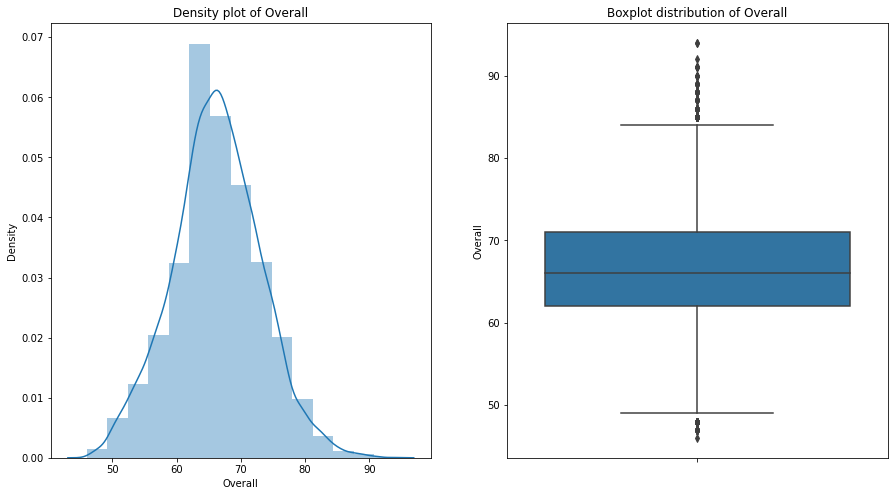

```python
fig, ax= plt.subplots(1, 2, figsize=(15,8))

sns.distplot(data['Overall'], bins=15, ax=ax[0])
ax[0].set_title('Density plot of Overall')
sns.boxplot(y=data['Overall'], ax=ax[1])
ax[1].set_title('Boxplot distribution of Overall')
plt.show()
```

OBSERVATIONS:

1. The density plot is normally distributed
2. The boxplot identifies outliers. So outlier treatment needs to be done before training the data for any model

```python
#11. retrieve the names of first 20 players  based on overall rating
data['Rank']= data['Overall'].rank(method ='dense', ascending=False)
top20 = data.sort_values(['Rank', 'Value'], ascending =[True,False]).head(20)
print(top20['Name'])
```

```
0              L. Messi
1     Cristiano Ronaldo
2             Neymar Jr
4          K. De Bruyne
5             E. Hazard
7             L. Suárez
3                De Gea
6             L. Modrić
8          Sergio Ramos
10       R. Lewandowski
11             T. Kroos
9              J. Oblak
13          David Silva
12             D. Godín
15            P. Dybala
16              H. Kane
17         A. Griezmann
23            S. Agüero
14             N. Kanté
21            E. Cavani
Name: Name, dtype: object
```

1. Generate a dataframe which should include all the information of the Top 20 players based on the Overall rating.

```python
dframe = top20.copy()
print(dframe)
```

```
                 Name  Age Nationality  Overall  Potential  \
0            L. Messi   31   Argentina       94         94
1   Cristiano Ronaldo   33    Portugal       94         94
2           Neymar Jr   26      Brazil       92         93
4        K. De Bruyne   27     Belgium       91         92
5           E. Hazard   27     Belgium       91         91
7           L. Suárez   31     Uruguay       91         91
3              De Gea   27       Spain       91         93
6           L. Modrić   32     Croatia       91         91
8        Sergio Ramos   32       Spain       91         91
10     R. Lewandowski   29      Poland       90         90
11           T. Kroos   28     Germany       90         90
9            J. Oblak   25    Slovenia       90         93
13        David Silva   32       Spain       90         90
12           D. Godín   32     Uruguay       90         90
```

[output cut: 96 more lines]

Q13. What is the average "Age" and "Wage" of these top 20 players?

```python
print("The average age of the first 20 players is ", top20['Age'].mean(), 'years')
```

```
The average age of the first 20 players is  28.75 years
```

```python
print("The average wage of the first 20 players is ", top20['Wage'].mean(), 'K')
```

```
The average wage of the first 20 players is  290700.0 K
```

Q14. Among the top 20 players based on the Overall rating, which player has the highest wage? Display the name of the player with his wage.

```python
highest_paid = top20['Wage'].max()
print(" highest wage is ", highest_paid)
```

```
 highest wage is  565000.0
```

```python
for index, i in top20.iterrows():
    if i['Wage']==highest_paid:
        print(i['Name'], 'gets the highest pay ', highest_paid)
        break
```

```
L. Messi gets the highest pay  565000.0
```

Q15. Generate a dataframe which should include the "Player name", "Club Name", "Wage", and 'Overall rating'.

- i) find the average Overall rating for each club.
- ii) Display the average overall rating of Top10 Clubs using a plot

```python
new_dataframe = data[['Name', 'Club', 'Wage', 'Overall']].copy()
new_dataframe
```

|  | Name | Club | Wage | Overall |
| --- | --- | --- | --- | --- |
| 0 | L. Messi | FC Barcelona | 565000.0 | 94 |
| 1 | Cristiano Ronaldo | Juventus | 405000.0 | 94 |
| 2 | Neymar Jr | Paris Saint-Germain | 290000.0 | 92 |
| 3 | De Gea | Manchester United | 260000.0 | 91 |
| 4 | K. De Bruyne | Manchester City | 355000.0 | 91 |
| ... | ... | ... | ... | ... |
| 18202 | J. Lundstram | Crewe Alexandra | 1000.0 | 47 |
| 18203 | N. Christoffersson | Trelleborgs FF | 1000.0 | 47 |
| 18204 | B. Worman | Cambridge United | 1000.0 | 47 |
| 18205 | D. Walker-Rice | Tranmere Rovers | 1000.0 | 47 |
| 18206 | G. Nugent | Tranmere Rovers | 1000.0 | 46 |

18207 rows × 4 columns

```python
print(new_dataframe.groupby('Club')['Overall'].mean())
```

```
Club
 SSV Jahn Regensburg     65.586207
1. FC Heidenheim 1846    65.750000
1. FC Kaiserslautern     63.384615
1. FC Köln               70.785714
1. FC Magdeburg          65.615385
                           ...
Zagłębie Sosnowiec       60.760000
Çaykur Rizespor          66.900000
Örebro SK                60.481481
Östersunds FK            63.545455
Śląsk Wrocław            62.200000
Name: Overall, Length: 651, dtype: float64
```

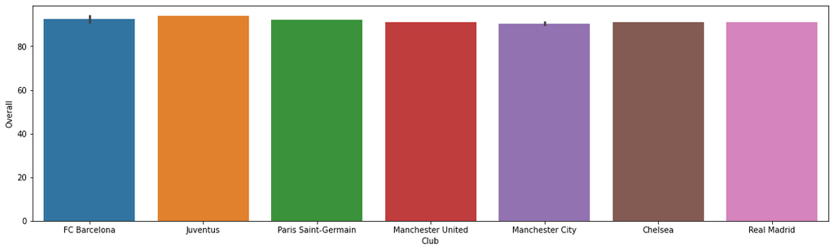

```
                 Name                 Club      Wage  Overall  Rank
0            L. Messi         FC Barcelona  565000.0       94   1.5
1   Cristiano Ronaldo             Juventus  405000.0       94   1.5
2           Neymar Jr  Paris Saint-Germain  290000.0       92   3.0
3              De Gea    Manchester United  260000.0       91   6.5
4        K. De Bruyne      Manchester City  355000.0       91   6.5
5           E. Hazard              Chelsea  340000.0       91   6.5
6           L. Modrić          Real Madrid  420000.0       91   6.5
7           L. Suárez         FC Barcelona  455000.0       91   6.5
8        Sergio Ramos          Real Madrid  380000.0       91   6.5
13        David Silva      Manchester City  285000.0       90  12.0
```

```python
new_dataframe['Rank']= new_dataframe['Overall'].rank(method= 'average', ascending= False)
top10= new_dataframe.sort_values(['Rank'], ascending =[True]).head(10)
plt.figure(figsize=(18,5))
sns.barplot(y= 'Overall', x= 'Club', data= top10)
plt.show()
print(top10)
```

Q16. What is the relationship between age and individual potential of the player? Visualize the relationship with appropriate plot and Comment on the same.

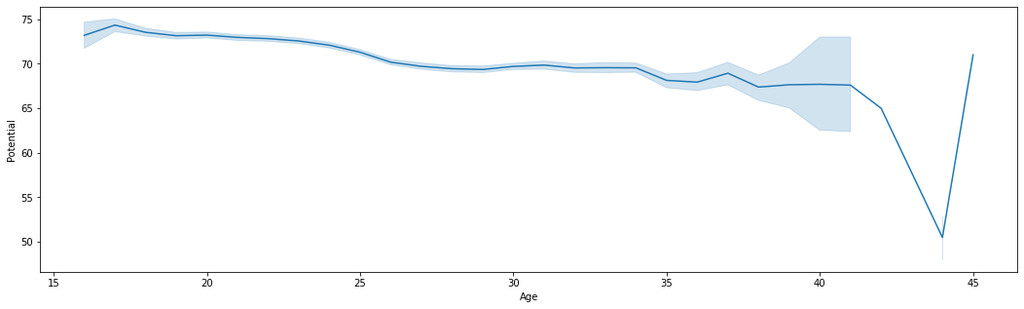

```python
data1=data.copy()
plt.figure(figsize=(18,5))
sns.lineplot(x= 'Age', y= 'Potential', data = data1)
plt.show()
```

As age increases, the potential is seen to decrease in the players, except for few. There are outliers in the above graph

Q17.Which features directly contribute to the wages of the players? Support your answer with a plot and a metric. (hint: use potential, Overall, value, international reputation, and Release Clause)

```python
target = data['Wage']
```

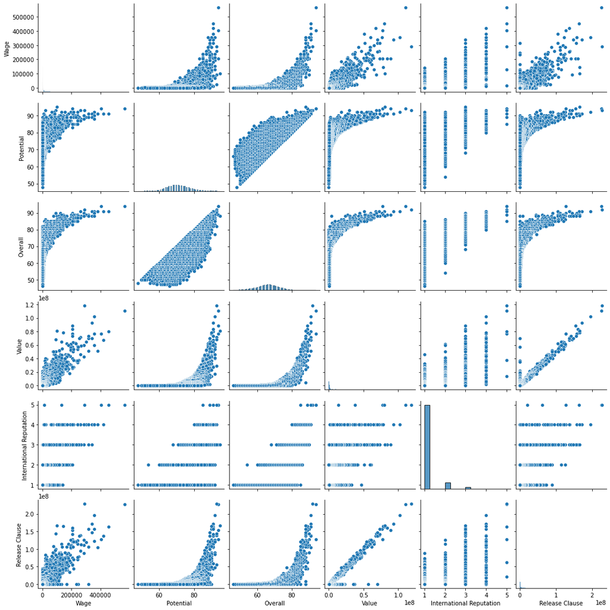

```python
cols= ['Wage', 'Potential', 'Overall', 'Value', 'International Reputation', 'Release Clause']
sns.pairplot(data[cols])
plt.show()
```

```python
# Displaying the  correlation between the columns
data[cols].corr()
```

|  | Wage | Potential | Overall | Value | International Reputation | Release Clause |
| --- | --- | --- | --- | --- | --- | --- |
| Wage | 1.000000 | 0.486413 | 0.571926 | 0.858442 | 0.668635 | 0.820162 |
| Potential | 0.486413 | 1.000000 | 0.660939 | 0.576218 | 0.372993 | 0.547668 |
| Overall | 0.571926 | 0.660939 | 1.000000 | 0.627085 | 0.499491 | 0.589200 |
| Value | 0.858442 | 0.576218 | 0.627085 | 1.000000 | 0.653176 | 0.967255 |
| International Reputation | 0.668635 | 0.372993 | 0.499491 | 0.653176 | 1.000000 | 0.618094 |
| Release Clause | 0.820162 | 0.547668 | 0.589200 | 0.967255 | 0.618094 | 1.000000 |

```python
#position in the pitch where the maximum number of players play and the position where the minimum number of players play
p= data.groupby('Position').count()
print(p)
```

```
          Name   Age  Nationality  Overall  Potential  Club  Value  Wage  \
Position
CAM        958   958          958      958        958   948    958   958
CB        1778  1778         1778     1778       1778  1754   1778  1778
CDM        948   948          948      948        948   936    948   948
CF          74    74           74       74         74    74     74    74
CM        1394  1394         1394     1394       1394  1377   1394  1394
GK        2025  2025         2025     2025       2025  1992   2025  2025
LAM         21    21           21       21         21    21     21    21
LB        1322  1322         1322     1322       1322  1305   1322  1322
LCB        648   648          648      648        648   637    648   648
LCM        395   395          395      395        395   389    395   395
LDM        243   243          243      243        243   239    243   243
LF          15    15           15       15         15    15     15    15
LM        1095  1095         1095     1095       1095  1086   1095  1095
LS         207   207          207      207        207   206    207   207
LW         381   381          381      381        381   374    381   381
LWB         78    78           78       78         78    78     78    78
RAM         21    21           21       21         21    21     21    21
RB        1291  1291         1291     1291       1291  1268   1291  1291
RCB        662   662          662      662        662   652    662   662
RCM        391   391          391      391        391   387    391   391
RDM        248   248          248      248        248   246    248   248
RF          16    16           16       16         16    16     16    16
RM        1124  1124         1124     1124       1124  1114   1124  1124
RS         203   203          203      203        203   201    203   203
RW         370   370          370      370        370   365    370   370
RWB         87    87           87       87         87    87     87    87
ST        2152  2152         2152     2152       2152  2130   2152  2152

          Preferred Foot  International Reputation  ...  Marking  \
Position                                            ...
CAM                  958                       958  ...      958
CB                  1778                      1778  ...     1778
CDM                  948                       948  ...      948
CF                    74                        74  ...       74
CM                  1394                      1394  ...     1394
GK                  2025                      2025  ...     2025
LAM                   21                        21  ...       21
LB                  1322                      1322  ...     1322
```

[output cut: 66 more lines]

```
LW                  381         381             381   381
LWB                  78          78              78    78
RAM                  21          21              21    21
RB                 1291        1291            1291  1291
RCB                 662         662             662   662
RCM                 391         391             391   391
RDM                 248         248             248   248
RF                   16          16              16    16
RM                 1124        1124            1124  1124
RS                  203         203             203   203
RW                  370         370             370   370
RWB                  87          87              87    87
ST                 2152        2152            2152  2152

[27 rows x 53 columns]
```

Q19. How many players are from the club 'Juventus' and the wage is greater than 200K? Display all the information of such players.

```python
data1= data[data['Club']== 'Juventus']
```

```python
data1= data1[data1['Wage']>200000]
print(data1)
```

```
                 Name  Age Nationality  Overall  Potential      Club  \
1   Cristiano Ronaldo   33    Portugal       94         94  Juventus
15          P. Dybala   24   Argentina       89         94  Juventus
24       G. Chiellini   33       Italy       89         89  Juventus

         Value      Wage Preferred Foot  International Reputation  ...  \
1   77000000.0  405000.0          Right                       5.0  ...
15  89000000.0  205000.0           Left                       3.0  ...
24  27000000.0  215000.0           Left                       4.0  ...

    Marking  StandingTackle SlidingTackle GKDiving GKHandling  GKKicking  \
1      28.0            31.0          23.0      7.0       11.0       15.0
15     23.0            20.0          20.0      5.0        4.0        4.0
24     93.0            93.0          90.0      3.0        3.0        2.0

   GKPositioning  GKReflexes  Release Clause  Rank
1           14.0        11.0     127100000.0   1.0
15           5.0         8.0     153500000.0   5.0
24           4.0         3.0      44600000.0   5.0

[3 rows x 54 columns]
```

Q20. Generate a data frame containing top 5 players by Overall rating for each unique position.

```python
# generating a dataframe containing top 5 players by overall rating for each unique position
datafr = data.groupby(by = ['Position']).apply(lambda x: x.sort_values('Overall', ascending = False).head(5))
datafr
```

| Position |  | Name | Age | Nationality | Overall | Potential | Club | Value | Wage | Preferred Foot | International Reputation | ... | Marking | StandingTackle | SlidingTackle | GKDiving | GKHandling | GKKicking | GKPositioning | GKReflexes | Release Clause | Rank |
| --- | --- | --- | --- | --- | --- | --- | --- | --- | --- | --- | --- | --- | --- | --- | --- | --- | --- | --- | --- | --- | --- | --- |
| CAM | 17 | A. Griezmann | 27 | France | 89 | 90 | Atlético Madrid | 78000000.0 | 145000.0 | Left | 4.0 | ... | 59.0 | 47.0 | 48.0 | 14.0 | 8.0 | 14.0 | 13.0 | 14.0 | 165800000.0 | 5.0 |
|  | 31 | C. Eriksen | 26 | Denmark | 88 | 91 | Tottenham Hotspur | 73500000.0 | 205000.0 | Right | 3.0 | ... | 59.0 | 57.0 | 22.0 | 9.0 | 14.0 | 7.0 | 7.0 | 6.0 | 141500000.0 | 6.0 |
|  | 61 | Roberto Firmino | 26 | Brazil | 86 | 87 | Liverpool | 53000000.0 | 195000.0 | Right | 3.0 | ... | 60.0 | 64.0 | 42.0 | 8.0 | 11.0 | 9.0 | 6.0 | 10.0 | 104700000.0 | 8.0 |
|  | 66 | T. Müller | 28 | Germany | 86 | 86 | FC Bayern München | 45000000.0 | 135000.0 | Right | 4.0 | ... | 44.0 | 41.0 | 44.0 | 6.0 | 7.0 | 11.0 | 14.0 | 14.0 | 74300000.0 | 8.0 |
|  | 74 | M. Özil | 29 | Germany | 86 | 86 | Arsenal | 43500000.0 | 190000.0 | Left | 4.0 | ... | 24.0 | 16.0 | 19.0 | 6.0 | 14.0 | 10.0 | 6.0 | 14.0 | 82700000.0 | 8.0 |
| ... | ... | ... | ... | ... | ... | ... | ... | ... | ... | ... | ... | ... | ... | ... | ... | ... | ... | ... | ... | ... | ... | ... |
| ST | 1 | Cristiano Ronaldo | 33 | Portugal | 94 | 94 | Juventus | 77000000.0 | 405000.0 | Right | 5.0 | ... | 28.0 | 31.0 | 23.0 | 7.0 | 11.0 | 15.0 | 14.0 | 11.0 | 127100000.0 | 1.0 |
|  | 10 | R. Lewandowski | 29 | Poland | 90 | 90 | FC Bayern München | 77000000.0 | 205000.0 | Right | 4.0 | ... | 34.0 | 42.0 | 19.0 | 15.0 | 6.0 | 12.0 | 8.0 | 10.0 | 127100000.0 | 4.0 |
|  | 16 | H. Kane | 24 | England | 89 | 91 | Tottenham Hotspur | 83500000.0 | 205000.0 | Right | 3.0 | ... | 56.0 | 36.0 | 38.0 | 8.0 | 10.0 | 11.0 | 14.0 | 11.0 | 160700000.0 | 5.0 |
|  | 23 | S. Agüero | 30 | Argentina | 89 | 89 | Manchester City | 64500000.0 | 300000.0 | Right | 4.0 | ... | 30.0 | 20.0 | 12.0 | 13.0 | 15.0 | 6.0 | 11.0 | 14.0 | 119300000.0 | 5.0 |
|  | 36 | G. Bale | 28 | Wales | 88 | 88 | Real Madrid | 60000000.0 | 355000.0 | Left | 4.0 | ... | 54.0 | 55.0 | 52.0 | 15.0 | 15.0 | 11.0 | 5.0 | 6.0 | 123000000.0 | 6.0 |

135 rows × 54 columns

```python
datafr['Name'].duplicated().sum()
```

```
0
```

Q21. What is the average wage one can expect to pay for the top 5 players in every position?

```python
#displaying only the wage
data['Wage']
```

```
0        565000.0
1        405000.0
2        290000.0
3        260000.0
4        355000.0
           ...
18202      1000.0
18203      1000.0
18204      1000.0
18205      1000.0
18206      1000.0
Name: Wage, Length: 18207, dtype: float64
```

```python
#average wage one can expect to pay for the top 5 players in every position using datafr created in Q19
avg_wage= datafr['Wage'].groupby('Position').apply(np.mean)
print(avg_wage)
```

```
Position
CAM    174000.0
CB     139600.0
CDM    217000.0
CF      47400.0
CM     130600.0
GK     192800.0
LAM     81600.0
LB     177200.0
LCB    162000.0
LCM    184400.0
LDM    126600.0
LF     121200.0
LM     164600.0
LS     130200.0
LW     261000.0
LWB     34200.0
RAM     45400.0
RB     155400.0
RCB    231000.0
RCM    240800.0
RDM    105000.0
RF     148000.0
RM     131400.0
RS     132200.0
RW     202000.0
RWB     44200.0
ST     294000.0
Name: Wage, dtype: float64
```